```python
from IPython.core.display import display, HTML
display(HTML("<style>.container { width:80% !important; }</style>"))
```

```python
import pandas as pd
import numpy as np
import matplotlib.pyplot as py
```

# Analyzing responses to rate the usefulness of a feature of a software tool

#### Objective of the survey:

The objective of the survey is to solicit feedback from subjects in order to evaluate the responses to rate the usefulness of a software tool. This helps us understand usefulness of our software tool to users and also the shortcoming of the software tool inturn helping us understand the areas of improvement to better the user experience using the software.

- Understand the effectivness and expressiveness of the Data/Task Abstraction component.
- Understand the effectiveness and epressiveness of the Visual Encoding/Interaction Idiom component.
- Process collected responses.

#### Questionaire Response collection

As we can see from the dataset the entire survey has been conducted using a 5 point scale rating system. This can be considered as a likert scale rating system.

25 subjects were presented with 11 questions to understand different areas of the software usage and respective responses were recorded into a matrix of 25 X 11 where each row represented different user and each column corresponds to each question that was presented to the user.

I have renamed the columns as Q1, Q2, Q3......Q11 and also have renamed the first column as "Respondants". The dataset before and after the renaming of columns are shown below:

Before Renaming:

```python
df_old = pd.read_excel("Evaluation-Table1.xlsx")
df_old
```

|  | 1 | 2 | 4 | 5 | 6 | 7 | 8 | 10 | 11 | 12 | 13 |
| --- | --- | --- | --- | --- | --- | --- | --- | --- | --- | --- | --- |
| 1 | 4 | 4 | 4 | 4 | 4 | 3 | 3 | 3 | 4 | 4 | 2 |
| 2 | 4 | 3 | 4 | 4 | 3 | 4 | 4 | 4 | 4 | 5 | 1 |
| 3 | 3 | 3 | 4 | 3 | 4 | 5 | 5 | 4 | 5 | 2 | 1 |
| 4 | 4 | 3 | 5 | 4 | 3 | 4 | 3 | 5 | 4 | 3 | 1 |
| 5 | 4 | 4 | 2 | 3 | 4 | 4 | 4 | 4 | 4 | 2 | 2 |
| 6 | 4 | 4 | 4 | 4 | 3 | 4 | 4 | 4 | 5 | 3 | 3 |
| 7 | 4 | 3 | 3 | 3 | 4 | 5 | 4 | 5 | 4 | 2 | 5 |
| 8 | 4 | 2 | 2 | 2 | 3 | 1 | 1 | 3 | 5 | 3 | 2 |
| 9 | 4 | 5 | 5 | 4 | 4 | 5 | 4 | 4 | 4 | 1 | 2 |
| 10 | 4 | 4 | 5 | 5 | 3 | 4 | 5 | 4 | 3 | 2 | 2 |
| 11 | 4 | 3 | 3 | 4 | 3 | 3 | 4 | 3 | 5 | 1 | 2 |
| 12 | 4 | 4 | 3 | 4 | 3 | 4 | 3 | 3 | 4 | 4 | 2 |
| 13 | 4 | 3 | 5 | 5 | 3 | 4 | 4 | 4 | 4 | 2 | 2 |
| 14 | 4 | 4 | 3 | 4 | 4 | 3 | 5 | 3 | 4 | 3 | 2 |
| 15 | 4 | 3 | 4 | 5 | 5 | 5 | 5 | 4 | 4 | 2 | 2 |
| 16 | 5 | 4 | 4 | 3 | 4 | 4 | 4 | 3 | 5 | 3 | 3 |
| 17 | 4 | 5 | 5 | 5 | 4 | 4 | 4 | 4 | 4 | 3 | 3 |
| 18 | 4 | 4 | 4 | 4 | 3 | 4 | 5 | 4 | 4 | 3 | 3 |
| 19 | 5 | 5 | 5 | 5 | 5 | 5 | 5 | 5 | 5 | 4 | 3 |
| 20 | 4 | 4 | 5 | 3 | 2 | 3 | 3 | 3 | 4 | 5 | 2 |
| 21 | 2 | 2 | 4 | 4 | 3 | 4 | 4 | 3 | 4 | 1 | 3 |
| 22 | 4 | 5 | 5 | 5 | 5 | 5 | 5 | 4 | 5 | 1 | 5 |
| 23 | 3 | 3 | 4 | 2 | 3 | 4 | 3 | 4 | 4 | 2 | 1 |
| 24 | 3 | 3 | 4 | 4 | 3 | 3 | 3 | 4 | 4 | 2 | 2 |
| 25 | 4 | 3 | 3 | 4 | 3 | 4 | 4 | 4 | 4 | 2 | 2 |

After Renaming:

```python
df_new = pd.read_excel("Evaluation-Table2.xlsx")
df_new
```

|  | Respondents | Q1 | Q2 | Q4 | Q5 | Q6 | Q7 | Q8 | Q10 | Q11 | Q12 | Q13 |
| --- | --- | --- | --- | --- | --- | --- | --- | --- | --- | --- | --- | --- |
| 0 | 1 | 4 | 4 | 4 | 4 | 4 | 3 | 3 | 3 | 4 | 4 | 2 |
| 1 | 2 | 4 | 3 | 4 | 4 | 3 | 4 | 4 | 4 | 4 | 5 | 1 |
| 2 | 3 | 3 | 3 | 4 | 3 | 4 | 5 | 5 | 4 | 5 | 2 | 1 |
| 3 | 4 | 4 | 3 | 5 | 4 | 3 | 4 | 3 | 5 | 4 | 3 | 1 |
| 4 | 5 | 4 | 4 | 2 | 3 | 4 | 4 | 4 | 4 | 4 | 2 | 2 |
| 5 | 6 | 4 | 4 | 4 | 4 | 3 | 4 | 4 | 4 | 5 | 3 | 3 |
| 6 | 7 | 4 | 3 | 3 | 3 | 4 | 5 | 4 | 5 | 4 | 2 | 5 |
| 7 | 8 | 4 | 2 | 2 | 2 | 3 | 1 | 1 | 3 | 5 | 3 | 2 |
| 8 | 9 | 4 | 5 | 5 | 4 | 4 | 5 | 4 | 4 | 4 | 1 | 2 |
| 9 | 10 | 4 | 4 | 5 | 5 | 3 | 4 | 5 | 4 | 3 | 2 | 2 |
| 10 | 11 | 4 | 3 | 3 | 4 | 3 | 3 | 4 | 3 | 5 | 1 | 2 |
| 11 | 12 | 4 | 4 | 3 | 4 | 3 | 4 | 3 | 3 | 4 | 4 | 2 |
| 12 | 13 | 4 | 3 | 5 | 5 | 3 | 4 | 4 | 4 | 4 | 2 | 2 |
| 13 | 14 | 4 | 4 | 3 | 4 | 4 | 3 | 5 | 3 | 4 | 3 | 2 |
| 14 | 15 | 4 | 3 | 4 | 5 | 5 | 5 | 5 | 4 | 4 | 2 | 2 |
| 15 | 16 | 5 | 4 | 4 | 3 | 4 | 4 | 4 | 3 | 5 | 3 | 3 |
| 16 | 17 | 4 | 5 | 5 | 5 | 4 | 4 | 4 | 4 | 4 | 3 | 3 |
| 17 | 18 | 4 | 4 | 4 | 4 | 3 | 4 | 5 | 4 | 4 | 3 | 3 |
| 18 | 19 | 5 | 5 | 5 | 5 | 5 | 5 | 5 | 5 | 5 | 4 | 3 |
| 19 | 20 | 4 | 4 | 5 | 3 | 2 | 3 | 3 | 3 | 4 | 5 | 2 |
| 20 | 21 | 2 | 2 | 4 | 4 | 3 | 4 | 4 | 3 | 4 | 1 | 3 |
| 21 | 22 | 4 | 5 | 5 | 5 | 5 | 5 | 5 | 4 | 5 | 1 | 5 |
| 22 | 23 | 3 | 3 | 4 | 2 | 3 | 4 | 3 | 4 | 4 | 2 | 1 |
| 23 | 24 | 3 | 3 | 4 | 4 | 3 | 3 | 3 | 4 | 4 | 2 | 2 |
| 24 | 25 | 4 | 3 | 3 | 4 | 3 | 4 | 4 | 4 | 4 | 2 | 2 |

#### Data Pre-Processing

The current format of dataset(one-row -per-respondent format) does not allow to derive very interesting patterns and also to create good visualization. So in order to improve the dataset format we have to understand the context of the questions so that we can create groupings, labels etc.

It is known that:

- Questions 1, 2 and 4 are in the same group. Each of these three questions asks the subjects to evaluate whether one (of the three) aspects of a visualization system was useful or not.
- Questions 5, 6 7 and 8 ask the subjects to provide a rating of one of the four important visualization components to ensure each component did help him/her understand a particular feature.
- Questions 10 and 11 ask the subjects for their experience in using the system to learn and to improve their previous study.
- Question 12 asks the subjects to report how long he/she took to understand the concept by using the visualization tool. The answers are range values as people may not be able to point out exactly how many minutes they have spent on the visualization system. Higher values mean longer time spent on the system.
- Question 13 asks how many times a subject used the visualization system in his/her study. The answers indicate ranges. Again, higher values means more times.

From the above known facts we can see that there are 5 high level groupings of the questions and we can name each of these groupings.

- Group1 (Q1, Q2, Q4) - Aspect of Visualization [here the rating imply how useful an aspect of Viz was]
- Group2 (Q5, Q6, Q7, Q8) - Visualization Components [here the rating imply how each component helped user understand a feature]
- Group3 (Q10, Q11) - Experience in using the system. [here the ratings imply how much experience user has using the system]
- Group4 (Q12) - Time to understand the concept [here the ratings imply time taken by user to understand a concept]
- Group5 (Q13) - Times visualization system was used by subject

We move ahead to labelling the ratings based on different groups. Most of the labels below are selected from recommended likert scale labelling obtained from a study by Iowa State University.

- For Group1 and Group2 the suitable labels for the ratings chosen are:

  ```
    1) Strongly Disagree
    2) Disagree
    3) Neutral
    4) Agree
    5) Strongly Agree
  ```

- For Group3:

  ```
    1) Novice
    2) Advanced beginner
    3) Competent
    4) Proficient
    5) Expert
  ```

- For Group4:

  ```
    1) Very Short
    2) Short
    3) Moderate
    4) Long
    5) Very Long
  ```

- For Group5:

  ```
    1) Never
    2) Rarely
    3) Normal
    4) Sometimes
    5) Most of the time
  ```

Now we further pivot and reshape the data to obtain a dataset as shown below:

[figure not shown]

#### Analysis:

In order to clearly visualize how software tool was useful for users and also to see a general user sentiment towards different areas of software tool I chose to use a Divergent Stacked Bar (Similar to a modified Gantt chart).

A divergent stacked bar chart is a juxtapose of a dual axis stacked bar chart and a bubble plot (showing the average rating for a given question and aspect of visualizations). The plot is as shown below:

[figure not shown]

To obtain the plot we had first derive some calculated Fields as shown below:

- First we divide the responses into "Positive Responses" and "Negative Rsponses".
- To calculate the positive responses, we have assumed any rating above "3" is considered positive and the rest as negative resposnses.
- We then calculate the average ratings for a given question show the value as circle plot(in few tools it is used as bubble plot).

The idea is based on sentiment analysis, where we divide the users into "Promoters"(users who rate high) and "Detractors"(users who rate low to neutral) and calculate "Percentage of positive responses" and "Percentage of negative responses".

In our case, Groups 1 and 2 indicate sentiment of the user towards different aspects of the visualization and Visualization components used.

1) It is clear from the above plot that users generally showed a positive response towards different aspects of the visualization system. However Q2 shows that users had a mixed feeling towards the second aspect of the visualization system used and hence needs some improvements to be made to better the user experience.

3) We see from Group3 Questions that most of the users who were part of the survey had very good experience using the system.

4) The most interesting insight was that even though most users had lot of experience using the system, the "Number of times the visualization system was used" was very low inturn a negative response to the system usage. This seem to be contradictory given that the "Time taken to understand a concept also seems to show that most users understand the concept in short time. Based on the given data it is difficult to show why we are seeing this reduction in users adapting the system as most features in our dataset show positive response.

We can also see this using a parallel coordinates as shown below:

[figure not shown]

##### How does the user responses look like over the entire question set?

[figure not shown]

One interesting pattern was between the users 8 and 9 as these users (as we can see below) have entirely different sentiment on the aspects and visualization components being used in the used, where user 8 has generally negative response while user 9 has generally positive response but the interesting fact is that both users (having almost similar experience using the system) have opted to not use the system in their study.

[figure not shown]

##### How different are the user responses given the questions posed to the users?

##### MANOVA - Multivariate analysis of variance

In order for us to use MANOVA we need to check if the data features have a good correlation as a MANOVA model on uncorrelated dimensions to not yield accurate results. To do that, I have plotted a correlation plot(using pearson method) and we can see that most features of the dataset show independence. Only Q8 and Q7 act as dependent variable given the independent variable "Responsents".

##### Null Hypothesis: The responses for Q7 and Q8 (third and fourth Visualization component) are same across users(independent variable)

##### Alternative hypothesis: Q7 and Q8 (third and fourth Visualization component) are significantly different across Respondents.

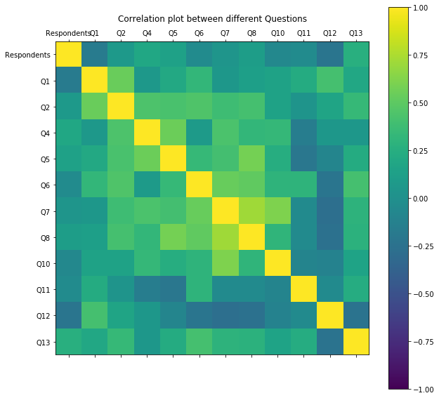

```python
import matplotlib.pyplot as plt

df = pd.read_excel("Evaluation-Table2.xlsx")
correlations = df.iloc[:,0:14].corr()
# plot correlation matrix
fig = plt.figure(figsize=(10,10))
ax = fig.add_subplot(111)
cax = ax.matshow(correlations, vmin=-1, vmax=1)
fig.colorbar(cax)
ticks = np.arange(0,12,1)
ax.set_xticks(ticks)
ax.set_yticks(ticks)
ax.set_xticklabels(df.columns.values)
ax.set_yticklabels(df.columns.values)
ax.set_title("Correlation plot between different Questions")
plt.show()
```

```python
correlations
```

[output not shown]

On creating a MANOVA model and summarizing the model, we get

```
      Df   Pillai    approx F   num Df den Df Pr(>F)
x      1    0.015469  0.17283    2      22    0.8424
```

Residuals 23

From above results we can see that "Pr(>F)" = 0.8424 which is greater than 95% confidence interval, Hence we can conclude that NULL Hypothesis is True and that there is no significant difference in responses for dependent variables Q7 and Q8 (third and fourth visualization component) across the respondents.

##### Are there any clusters or groupings among the responses from subjects?

This can be answered using a Cluster map which is a juxtaposed version of a dendogram and heatmap plots.

- A dendrogram is a tree diagram frequently used to illustrate the arrangement of the clusters produced by aglomerative hierarchical clustering.
- A heat map is a graphical representation of data where the individual values contained in a matrix are represented as colors.

Using a cluster map we can clearly see the ratings of users across the different areas of study of the software tools.

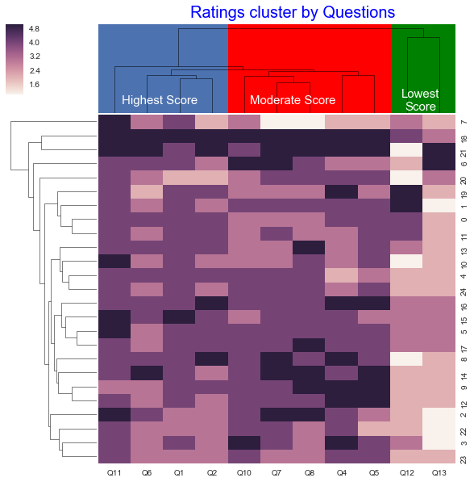

```python
import seaborn as sns
import matplotlib.patches as patches

ax = sns.clustermap(df.iloc[:,1:14])
ax.ax_col_dendrogram.add_patch(
    patches.Rectangle(
        (0, 0),   # (x,y)
        40,          # width
        10,          # height
    )
)
ax.ax_col_dendrogram.add_patch(
    patches.Rectangle(
        (40, 0),   # (x,y)
        50,          # width
        10,          # height
        facecolor="red"
    )
)
ax.ax_col_dendrogram.add_patch(
    patches.Rectangle(
        (90, 0),   # (x,y)
        30,          # width
        10,          # height
        facecolor="green"
    )
)
left, width = .25, .5
bottom, height = .25, .5
right = left + width
top = bottom + height
ax.fig.text(0.62*(left+right), 0.75*(bottom+top), 'Moderate Score',
        horizontalalignment='center',
        verticalalignment='center',
        fontsize=15, color='White')
ax.fig.text(0.84*(left+right), 0.75*(bottom+top), 'Lowest\nScore',
        horizontalalignment='center',
        verticalalignment='center',
        fontsize=15, color='White')
ax.fig.text(0.39*(left+right), 0.75*(bottom+top), 'Highest Score',
        horizontalalignment='center',
        verticalalignment='center',
        fontsize=15, color='White')
ax.fig.text(0.62*(left+right), 0.9*(bottom+top), 'Ratings cluster by Questions',
        horizontalalignment='center',
        verticalalignment='center',
        fontsize=20, color='blue')
py.show()
```